# Report on the working CellTag pipeline

Markus Heidrich

## Report

Show example run of data from Anika.

## Setup

### Load Libraries

libraries required to run this report.

```r
### Bioconductor and CRAN libraries used
library(knitr)
```

```r
library(ggplot2)
suppressMessages(library("CellTagR"))
suppressMessages(library("Seurat"))
suppressMessages(library("optparse"))
```

### Execution

We can execute all scripts via the control.sh script, which accepts arguments.

```bash
./control.sh cellTag --visualize --save_progress_name "anika" --tagged 1 --low_filter 1 --bam_data "data/bam/possorted_genome_bam.filtered_merged.bam"  --whitelist_version "v1" --sample_name "SI-TT-H4"
#./control.sh map --visualize_umap --runUMAP --visualize_ver v1 --save_progress_name "anika" --sample_name "SI-TT-H4" --min_cells 1 --min_features 2 --filter
```

After calling the script with arguments, the control.sh script executes one of its commands.

```bash
case $1 in
  preprocess)
    echo "sh scripts/preprocessing.sh '${@:2}'" >> data/Log.log
    sh scripts/preprocessing.sh "${@:2}"
    ;;
  cellTag)
  echo "sh scripts/cellTag.sh '${@:2}'" >> data/Log.log
    sh scripts/cellTag.sh "${@:2}"
    ;;
  network)
  echo "Rscript --vanilla scripts/network.R '${@:2}'" >> data/Log.log
    Rscript --vanilla scripts/network.R "${@:2}"
    ;;
  map)
  echo "Rscript --vanilla scripts/map_cellTags.R '${@:2}'" >> data/Log.log
    Rscript --vanilla scripts/map_cellTags.R "${@:2}"
    ;;
  --help)
    usage
    ;;
  *)
    echo "Invalid Argument $1"
    echo "Execute with --help for a list of arguments"
    exit 1
    ;;
esac
```

In this case it was the cellTag command, which then executes the cellTag bash script. This script is split into all the different parts of the cellTag pipeline needed to analyse the data.

```bash
while [[ $# -gt 0 ]]; do
  key="$1"
  case $key in
    --bam_data)
        bam_data=$2
        shift
        shift
        ;;
    --out)
        out=$2
        shift
        shift
        ;;
    --sample_name)
        sample_name=$2
        shift
        shift
        ;;
    --collapsing_name)
        collapsing_name=$2
        shift
        shift
        ;;
    --save_progress_name)
        save_progress_name=$2
        shift
        shift
        ;;
    --whitelist_version)
        whitelist_version=$2
        shift
        shift
        ;;
    --whitelist_path)
        whitelist_path=$2
        shift
        shift
        ;;
    --high_filter)
        high_filter=$2
        shift
        shift
        ;;
    --low_filter)
        low_filter=$2
        shift
        shift
        ;;
    --tagged)
        tagged=$2
        shift
        shift
        ;;
    --bamfilter)
        bamfilter=true
        shift
        ;;
    --visualize)
        visualize=true
        shift
        ;;
    --help)
        usage
        ;;
    *)
        echo "Invalid option: $key"
        exit 1
        ;;
  esac
done

# check if whitelist path got changed, if not, set whitelist
# path in accordance with specified version
if [ "$whitelist_path" = "$whitelist_path1" ]; then
    if [ "$whitelist_version" = "v2" ]; then
        whitelist_path="$whitelist_path2"
    elif [ "$whitelist_version" = "v3" ]; then
        whitelist_path="$whitelist_path3"
    fi
fi

gunzip data/samples/$sample_name/outs/filtered_feature_bc_matrix/barcodes.tsv.gz

Rscript --vanilla scripts/cell.R --out $out --bam_data $bam_data --collapsing_name $collapsing_name --save_progress_name $save_progress_name --whitelist_version $whitelist_version --sample_name $sample_name


if $visualize; then
Rscript --vanilla scripts/filtering_cloneCalling.R --out $out --collapsing_name "${save_progress_name}_${collapsing_name%.*}_result.txt" --save_progress_name $save_progress_name --whitelist_path $whitelist_path --whitelist_version $whitelist_version --high_filter $high_filter --low_filter $low_filter --tagged $tagged --visualize
else
Rscript --vanilla scripts/filtering_cloneCalling.R --out $out --collapsing_name "${save_progress_name}_${collapsing_name%.*}_result.txt" --save_progress_name $save_progress_name --whitelist_path $whitelist_path --whitelist_version $whitelist_version --high_filter $high_filter --low_filter $low_filter --tagged $tagged
fi

gzip data/samples/$sample_name/outs/filtered_feature_bc_matrix/barcodes.tsv
```

We first load all sequences from a specified library, and prepare the data for collapsing to filter out some parts of the data.

```r
option_list = list(
    make_option(c("--out"), type="character", default="data/out/anika/",
                help="output file dir", metavar="character"),
    make_option(c("--collapsing_name"), type="character", default="collapsing.txt",
                help="Name of collapsing file", metavar="character"),
    make_option(c("--save_progress_name"), type="character", default="test",
                help="Name appended to outputs to be saved", metavar="character"),
    make_option(c("--sample_name"), type="character", default="SI-TT-H4",
                help="Name of experiment sample", metavar="character"),
    make_option(c("--whitelist_version"), type="character", default="v1",
                help="Version of whitelist", metavar="character"),
    make_option(c("--bam_data"), type="character", default="data/bam/possorted_genome_bam.filtered.bam",
                help="Path from current dir to .bam file", metavar="character")
)

opt_parser = OptionParser(option_list=option_list)
opt = parse_args(opt_parser)

tryCatch(
{

# Set up the CellTag Object
if (file.exists(paste0(opt$out, opt$save_prograss_name, ".RDS"))) {
    bam.test.obj <- readRDS(paste0(opt$out, opt$save_progress_name, ".RDS"))
} else {
    bam.test.obj <- CellTagObject(object.name = "bam.cell.tag.obj", fastq.bam.directory = opt$bam_data)
}

bam.test.obj <- CellTagExtraction(bam.test.obj, celltag.version = opt$whitelist_version)

bam.test.obj <- CellTagMatrixCount(celltag.obj = bam.test.obj,
    barcodes.file = paste0("data/samples/", opt$sample_name, "/outs/filtered_feature_bc_matrix/barcodes.tsv"))

bam.test.obj <- CellTagDataForCollapsing(celltag.obj = bam.test.obj, output.file = paste0(opt$out, opt$whitelist_version, opt$save_progress_name, "_", opt$collapsing_name))

saveRDS(bam.test.obj, paste0(opt$out, opt$whitelist_version, opt$save_progress_name, ".RDS"))
saveRDS(bam.test.obj, paste0(opt$out, opt$save_progress_name, ".RDS"))

},
error = function(err) {
    # Print the error message
    print(paste("Error:", conditionMessage(err)))
    # Stop the execution of the program
    stop("Exiting the program.")
}
)
```

We then run starcode to do the actual filtering.

```bash
starcode -s --print-clusters $out${whitelist_version}${save_progress_name}_$collapsing_name > $out${whitelist_version}${save_progress_name}_${collapsing_name%.*}_result.txt
```

Then we load the filtered data, binarize it and filter further, before performing clone calling. We create some plots while filtering to show what happens.

```r
option_list = list(
    make_option(c("--visualize"), action="store_true", default=FALSE,
              help="Visualize filtering"),
    make_option(c("--out"), type="character", default="data/out/anika/",
              help="output file dir", metavar="character"),
    make_option(c("--collapsing_name"), type="character", default="collapsing_result.txt",
              help="Name of collapsing file", metavar="character"),
    make_option(c("--save_progress_name"), type="character", default="anika",
              help="Name appended to outputs to be saved", metavar="character"),
    make_option(c("--whitelist_version"), type="character", default="v1",
                help="Version of whitelist", metavar="character"),
    make_option(c("--whitelist_path"), type="character", default="data/whitelist/V1.CellTag.Whitelist.csv",
              help="Path of whitelist", metavar="character"),
    make_option(c("--high_filter"),  default=20,
              help="Upper bound for filtering celltags", metavar="int"),
    make_option(c("--low_filter"),  default=1,
              help="Lower bound for filtering celltags", metavar="int"),
    make_option(c("--tagged"),  default=1,
              help="When binarizing, the number of cellTags needed to consider cell as tagged", metavar="int")
)

opt_parser = OptionParser(option_list=option_list)
opt = parse_args(opt_parser)


GetCellTagCurrentVersionWorkingMatrix <- function(celltag.obj, slot.to.select) {
  curr.mtx <- slot(celltag.obj, slot.to.select)
  if (nrow(curr.mtx) <= 0) {
    return(curr.mtx)
  } else {
    curr.version <- celltag.obj@curr.version
    curr.mtx.sub <- curr.mtx[, which(startsWith(colnames(curr.mtx), curr.version))]
colnames(curr.mtx.sub) <- gsub(pattern = paste0(curr.version, "."), replacement = "", colnames(curr.mtx.sub))
full.mtx.sub <- curr.mtx.sub[!(Matrix::rowSums(is.na(curr.mtx.sub)) == ncol(curr.mtx.sub) | Matrix::rowSums(curr.mtx.sub == 0) == ncol(curr.mtx.sub)),]

    return(full.mtx.sub)
  }
}


MyMetricPlots <- function(celltag.obj) {

      obj.metric.filtered.count <- GetCellTagCurrentVersionWorkingMatrix(celltag.obj, "metric.filtered.count")
      obj.whitelisted.count <- GetCellTagCurrentVersionWorkingMatrix(celltag.obj, "whitelisted.count")

      if (ncol(obj.metric.filtered.count) <= 0) {
        if (ncol(obj.whitelisted.count) <= 0) {
          celltag.data <- GetCellTagCurrentVersionWorkingMatrix(celltag.obj, "binary.mtx")
        } else {
          celltag.data <- obj.whitelisted.count
        }
      } else {
        celltag.data <- obj.metric.filtered.count
      }

      CellTags.per.cell.whitelisted.pf <- Matrix::rowSums(celltag.data)
      CellTags.per.cell.avg <- mean(CellTags.per.cell.whitelisted.pf)
      CellTags.frequency.whitelisted.pf <- Matrix::colSums(celltag.data)
      CellTags.freq.avg <- mean(CellTags.frequency.whitelisted.pf)

      g = plot(CellTags.per.cell.whitelisted.pf, main = "CellTag Counts of Individual Cells", xlab = "Cell Index", ylab = "CellTag Counts")
      print(g)
      g = plot(CellTags.frequency.whitelisted.pf, main = "CellTag Occurrence Frequency Across All Cells", xlab = "Cell Index", ylab = "CellTag Frequency")
      print(g)

      hist_data <- hist(CellTags.per.cell.whitelisted.pf, plot = FALSE)
      counts = hist_data$counts
      midpoints = seq(1, length(counts))
      midpoints = midpoints[!counts==0]
      counts = counts[!counts==0]
      hist_df <- data.frame(counts = counts, midpoints=midpoints)
      g <- ggplot(hist_df, aes(x = factor(midpoints), y = counts)) +
              geom_bar(stat = "identity") +
              labs(x = "CellTag Counts", y = "Count") +
              ggtitle("Histogram of CellTag Counts of Individual Cells")
      print(g)


      hist_data <- hist(CellTags.frequency.whitelisted.pf, plot = FALSE)
      counts <- hist_data$counts
      midpoints <- hist_data$mids
      midpoints <- midpoints[counts != 0]
      counts <- counts[counts != 0]
      hist_df <- data.frame(counts = counts, midpoints = midpoints)

      # Create the histogram plot using ggplot
      g <- ggplot(hist_df, aes(x = factor(midpoints), y = counts)) +
        geom_bar(stat = "identity") +
        labs(x = "CellTag Occurrence Frequency", y = "Count") +
        ggtitle("Histogram of CellTag Occurrence Frequency Across All Cells")

      # Print the plot
      print(g)

      cat("Average: ", CellTags.per.cell.avg, "\n")
      cat("Frequency: ", CellTags.freq.avg, "\n")
}

DIR <- opt$out

bam.test.obj <- readRDS("data/out/anika/v1anika.RDS")

bam.test.obj <- CellTagDataPostCollapsing(celltag.obj = bam.test.obj, collapsed.rslt.file = "data/out/anika/v1anika_collapsing_result.txt")
```

```
## [1] "Processing data/out/anika/v1anika_collapsing_result.txt"
##
```

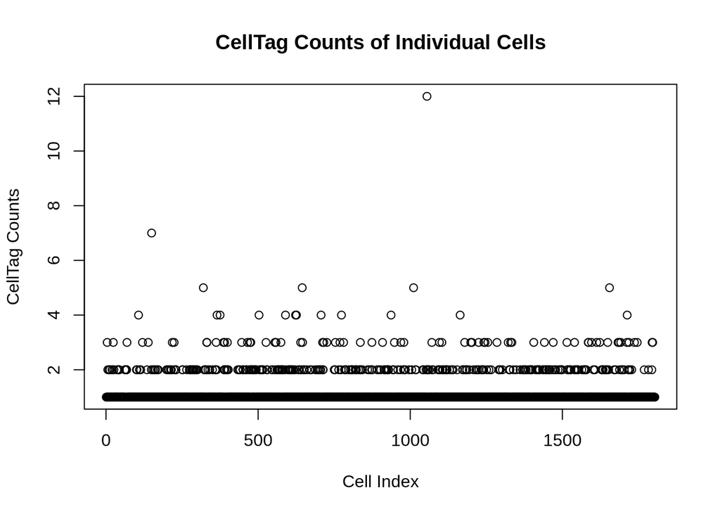

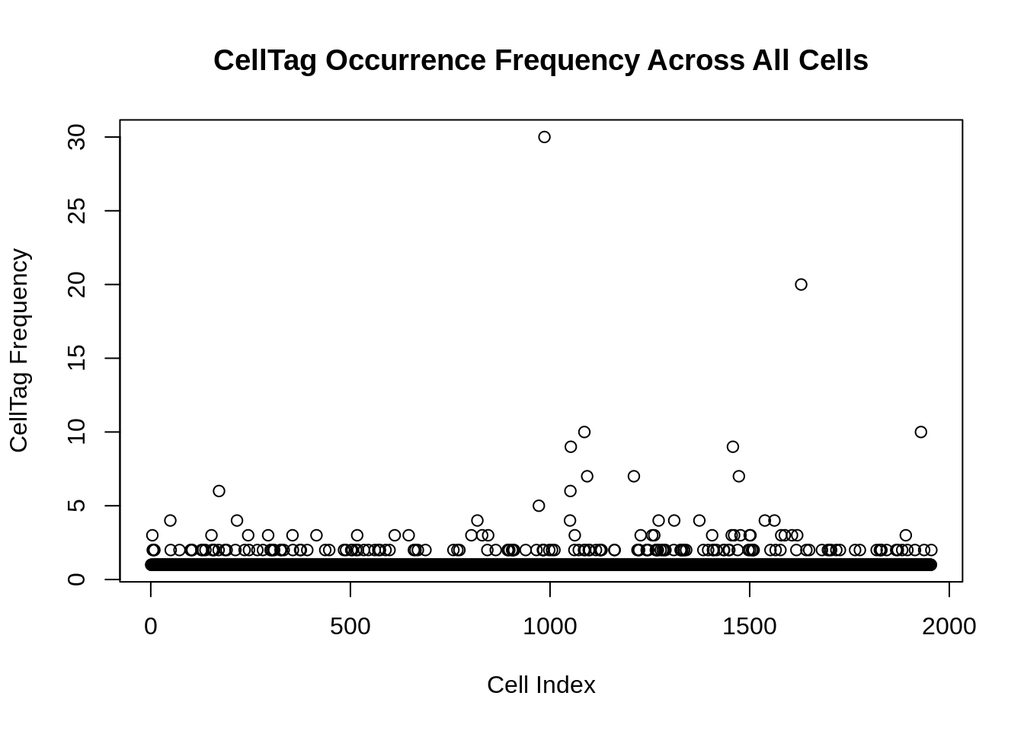

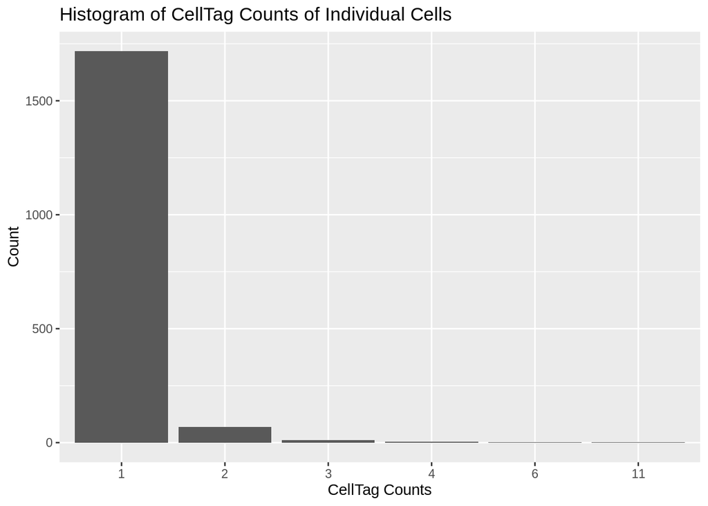

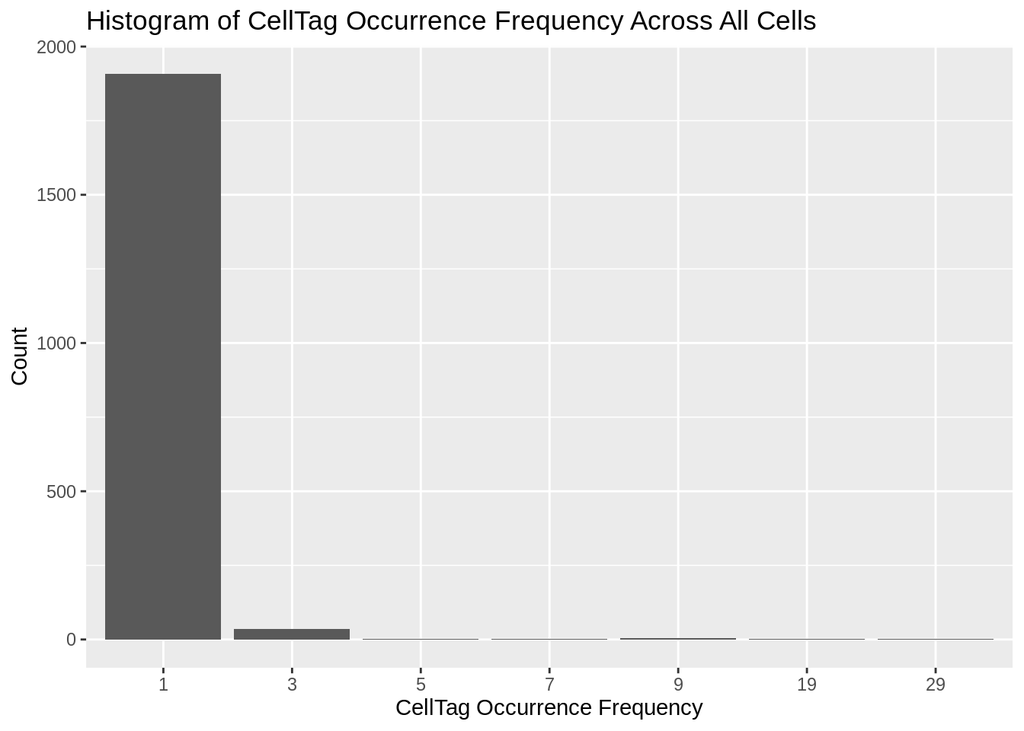

```
## Average:  1.273282
## Frequency:  1.174936
```

```r
bam.test.obj <- SingleCellDataBinarization(bam.test.obj, opt$tagged)


MyMetricPlots(bam.test.obj)
```

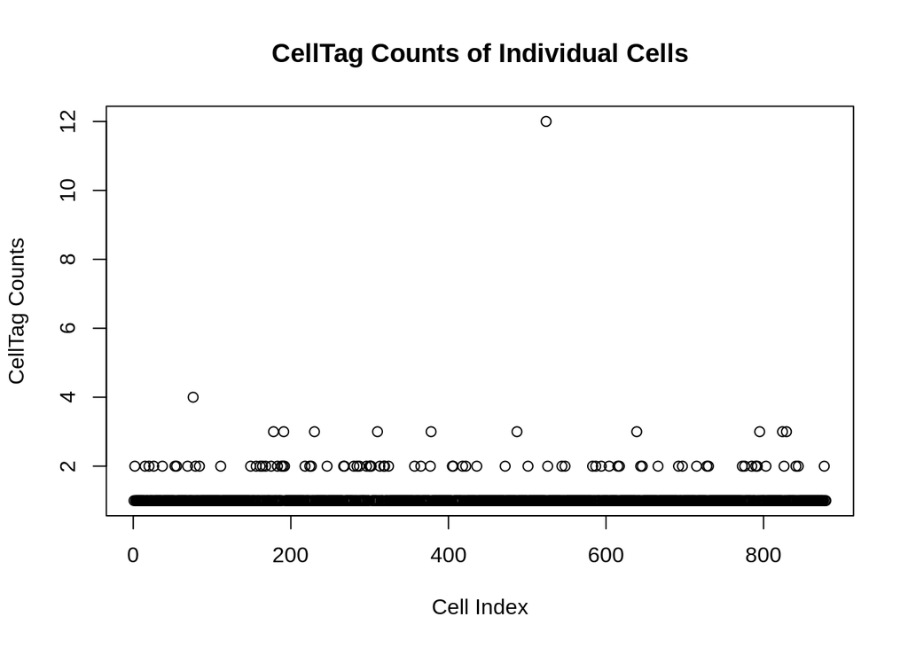

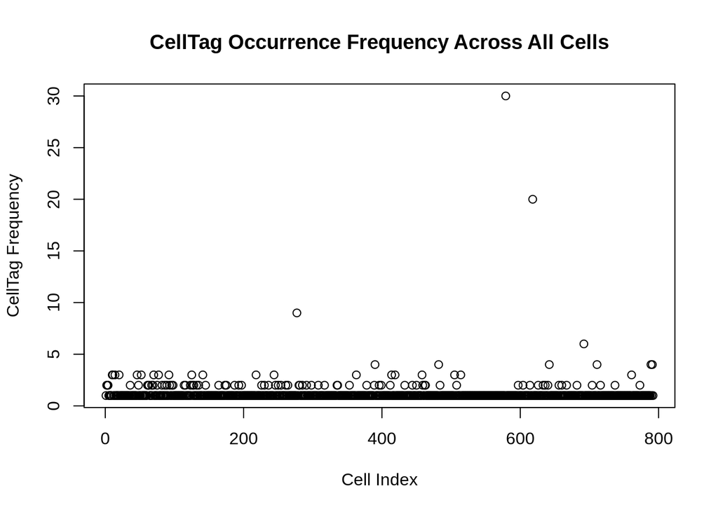

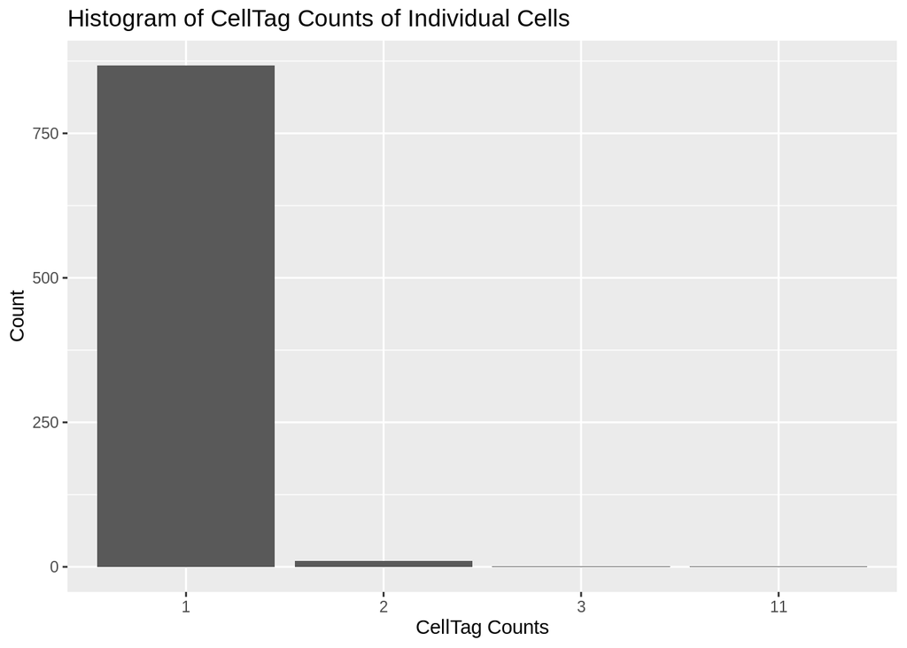

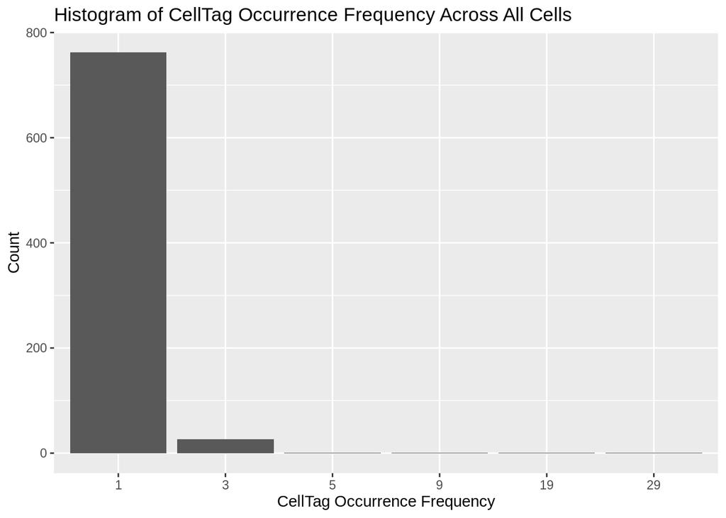

```
## Average:  1.124005
## Frequency:  1.247475
```

```r
# 4. Apply the whitelisted CellTags generated from assessment
bam.test.obj <- SingleCellDataWhitelist(bam.test.obj, opt$whitelist_path)


# 5. Check metric plots after whitelist filtering
# Recheck the metric similar to Step 3
MyMetricPlots(bam.test.obj)
```

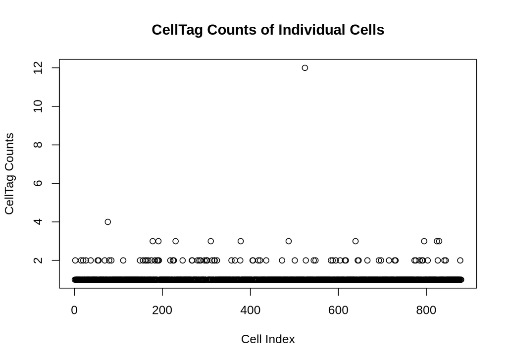

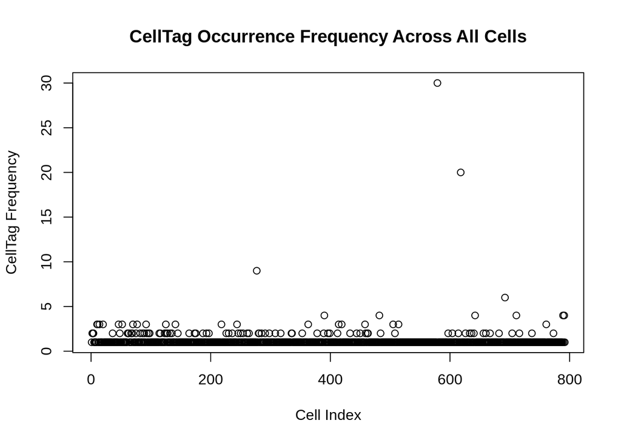

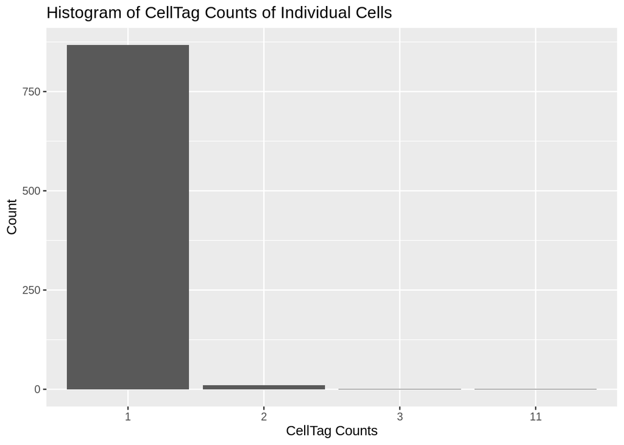

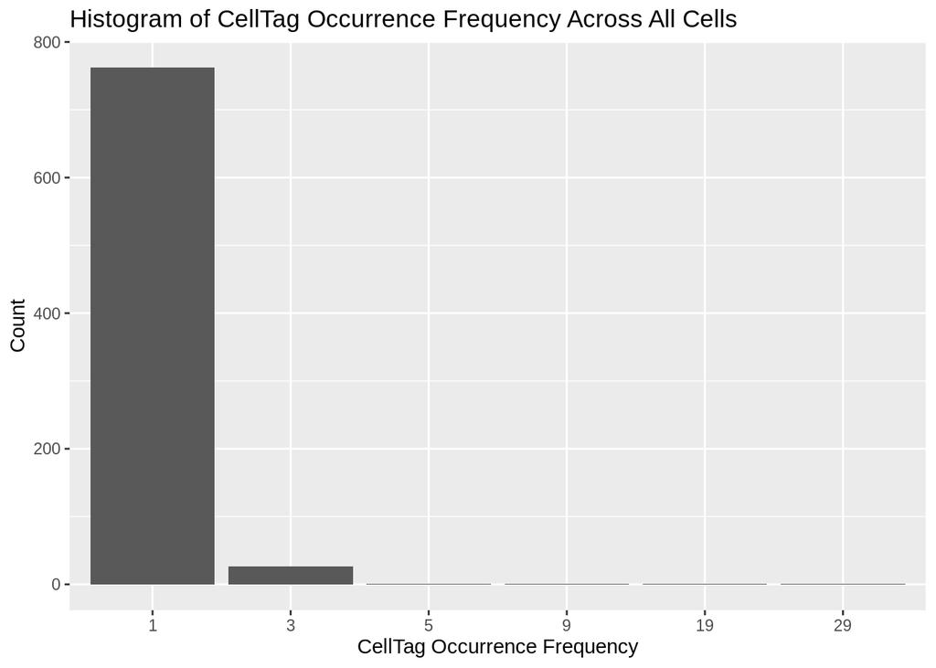

```
## Average:  1.124005
## Frequency:  1.247475
```

```r
# 6. Additional filtering
# Filter out cells with more than 20 CellTags
bam.test.obj@metric.filtered.count <- as(matrix(NA, 0, 0), "dgCMatrix")
bam.test.obj <- MetricBasedFiltering(bam.test.obj, opt$high_filter, comparison = "less")

# Filter out cells with less than 2 CellTags
bam.test.obj <- MetricBasedFiltering(bam.test.obj, opt$low_filter, comparison = "greater")


# 7. Last check of metric plots
MyMetricPlots(bam.test.obj)
```

```r
# 8. Clone Calling
# I. Jaccard Analysis
bam.test.obj <- JaccardAnalysis(bam.test.obj, fast=TRUE)

# Call clones
bam.test.obj <- CloneCalling(celltag.obj = bam.test.obj, correlation.cutoff=0.7)
```

## Map CellTags to cell clusters

```bash
#./control.sh cellTag --visualize --save_progress_name "anika" --tagged 1 --low_filter 1 --bam_data "data/bam/possorted_genome_bam.filtered_merged.bam"  --whitelist_version "v1" --sample_name "SI-TT-H4"
./control.sh map --visualize_umap --runUMAP --visualize_ver v1 --save_progress_name "anika" --sample_name "SI-TT-H4" --min_cells 1 --min_features 2 --filter
```

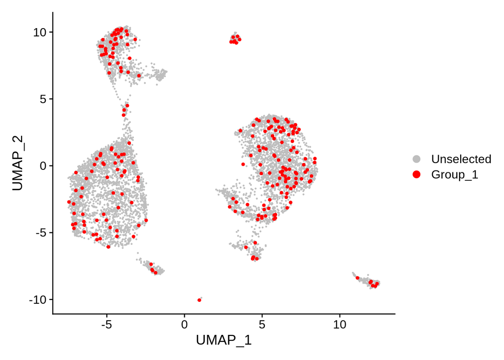

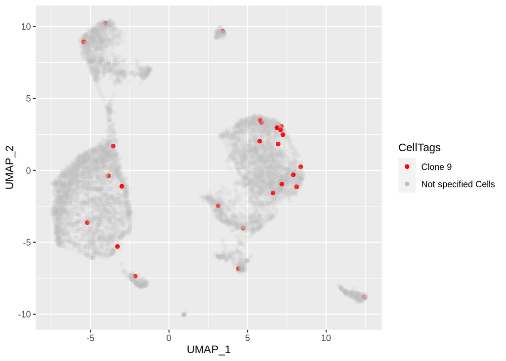

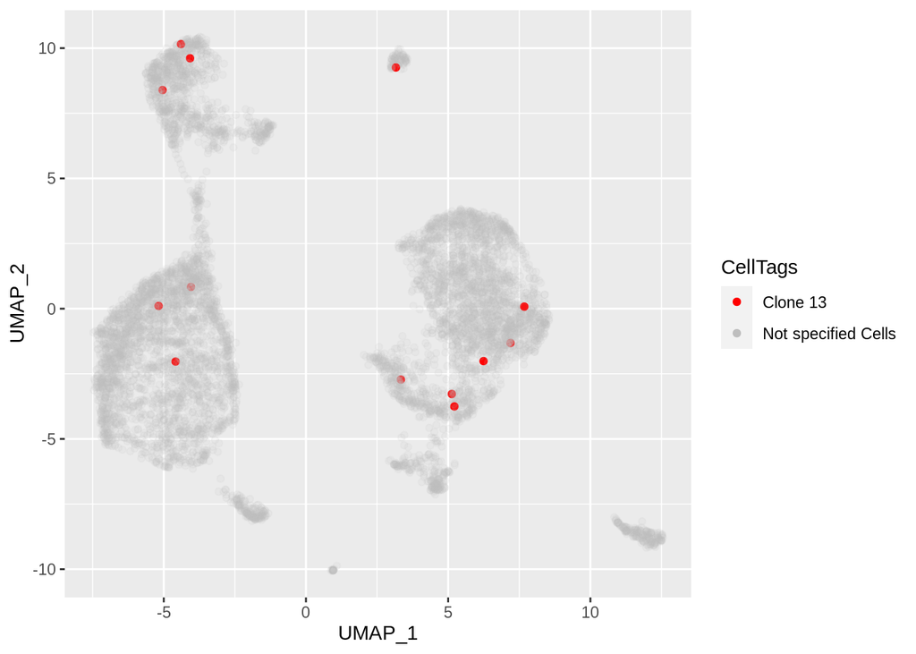

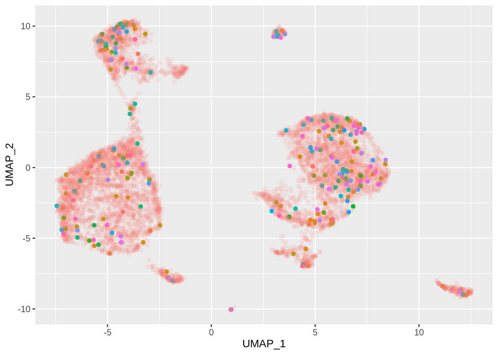

```r
option_list = list(
    make_option(c("--visualize_umap"), action="store_true", default=TRUE,
              help="Visualize filtering using umap"),
    make_option(c("--visualize_tsne"), action="store_true", default=FALSE,
              help="Visualize filtering using tsne"),
    make_option(c("--runUMAP"), action="store_true", default=FALSE,
              help="Run UMAP"),
    make_option(c("--runTSNE"), action="store_true", default=FALSE,
              help="Run TSNE"),
    make_option(c("--filter"), action="store_true", default=FALSE,
              help="Filter data"),
    make_option(c("--visualize_ver"), type="character", default="v1",
              help="visualize specified version, either v1, v2, v3 or all.", metavar="character"),
    make_option(c("--out"), type="character", default="data/out/",
              help="output file dir", metavar="character"),
    make_option(c("--vis_clone"),  default=1,
              help="Clone to visualize.", metavar="int"),
    make_option(c("--min_cells"),  default=1,
              help="Minimum cell count to load data.", metavar="int"),
    make_option(c("--min_features"),  default=1,
              help="Minimum features count to load data.", metavar="int"),
    make_option(c("--scale_factor"),  default=10000,
              help="Factor to scale cells with.", metavar="int"),
    make_option(c("--n_var_features"),  default=2000,
              help="Number of varible features to work with.", metavar="int"),
    make_option(c("--neighbours_dims"),  default=10,
              help="Number of PCAs for FindNeighbours to look at.", metavar="int"),
    make_option(c("--cluster_resolution"),  default=0.5,
              help="Resolution of clusters to calculate. Between 0 and 1.", metavar="float"),
    make_option(c("--save_progress_name"), type="character", default="insert",
              help="Name appended to outputs to be saved", metavar="character"),
    make_option(c("--sample_name"), type="character", default="SI-TT-H4",
                help="Name of experiment sample", metavar="character")
)

opt_parser = OptionParser(option_list=option_list)
opt = parse_args(opt_parser)

plot_umap_with_specific_clone <- function(pbmc, version, method, subset, subset_clust, clone) {
    # Create a data frame with reduction values from Seurat object
    if  (method=="umap") {
        red_df <- as.data.frame(pbmc@reductions$umap@cell.embeddings)
    } else if (method=="tsne") {
        red_df <- as.data.frame(pbmc@reductions$tsne@cell.embeddings)
    }

    red_df$subset <- "Not specified Cells"

    subset = subset[subset_clust==clone]

    # Assign colors to subsets in the data frame
    red_df$subset[rownames(red_df) %in% subset] <- paste0("Clone ", clone)
    red_df$alpha <- 1
    red_df$alpha[!rownames(red_df) %in% subset] <- NA

    # Plot the UMAP values with colored subsets
    if  (method=="umap") {
        plot <- ggplot(red_df, aes(UMAP_1, UMAP_2, color = subset)) +
          geom_point(alpha = ifelse(!is.na(red_df$alpha), 1, 0.1)) +
          scale_color_manual(values = c("red", "grey")) +
          labs(color = "CellTags")
    } else if (method=="tsne") {
        plot <- ggplot(red_df, aes(TSNE_1, TSNE_2, color = subset)) +
          geom_point(alpha = ifelse(!is.na(red_df$alpha), 1, 0.1)) +
          scale_color_manual(values = c("red", "grey")) +
          labs(color = "CellTags")
    }
    print(plot)
}


plot_umap_clones <- function(pbmc, version, method, subset, subset_clust) {
    # Create a data frame with reduction values from Seurat object
    if  (method=="umap") {
        red_df <- as.data.frame(pbmc@reductions$umap@cell.embeddings)
    } else if (method=="tsne") {
        red_df <- as.data.frame(pbmc@reductions$tsne@cell.embeddings)
    }

    red_df$subset <- "Not specified Cells"
    red_df$col <- 0
    indices_sub = which(rownames(red_df) %in% subset)
    red_df$col[indices_sub] = subset_clust
    red_df$col = as.factor(red_df$col)

    # Assign colors to subsets in the data frame
    red_df$subset[rownames(red_df) %in% subset] <- paste0("Clone ", opt$vis_clone)
    red_df$alpha <- 1
    red_df$alpha[!rownames(red_df) %in% subset] <- NA

    # Plot the UMAP values with colored subsets
    if  (method=="umap") {
        plot <- ggplot(red_df, aes(UMAP_1, UMAP_2, color = col)) +
          geom_point(alpha = ifelse(!is.na(red_df$alpha), 1, 0.1), show.legend = FALSE) +
          scale_color_discrete() +
          labs(color = "CellTags")
    } else if (method=="tsne") {
        plot <- ggplot(red_df, aes(TSNE_1, TSNE_2, color = subset)) +
          geom_point(alpha = ifelse(!is.na(red_df$alpha), 1, 0.1)) +
          scale_color_discrete() +
          labs(color = "CellTags")
    }
    print(plot)
}



bam.test.obj <- readRDS("data/out/anika/anika.RDS")

if (file.exists("data/out/anika/v1anika.RDS")) {
    bam.v1.obj <- readRDS("data/out/anika/v1anika.RDS")
    bam.test.obj@clone.composition$v1 = bam.v1.obj@clone.composition$v1
    v1 = bam.test.obj@clone.composition$v1$cell.barcode
    v1_clones = bam.test.obj@clone.composition$v1$clone.id
}

if (file.exists("data/out/anika/anika_reduction.RDS")) {
    pbmc = readRDS("data/out/anika/anika_reduction.RDS")
} else if (opt$filter) {
    pbmc.data <- Read10X(data.dir = paste0("data/samples/", opt$sample_name, "/outs/filtered_feature_bc_matrix/"))
    pbmc <- CreateSeuratObject(counts = pbmc.data, project = "test", min.cells = opt$min_cells, min.features = opt$min_features)

    pbmc <- NormalizeData(pbmc, normalization.method = "LogNormalize", scale.factor = opt$scale_factor)

    pbmc <- FindVariableFeatures(pbmc, selection.method = "vst", nfeatures = opt$n_var_features)

    all.genes <- rownames(pbmc)
    pbmc <- ScaleData(pbmc, features = all.genes)

    pbmc <- RunPCA(pbmc)

    pbmc <- FindNeighbors(pbmc, dims = 1:opt$neighbours_dims)
    pbmc <- FindClusters(pbmc, resolution = opt$cluster_resolution)
}

if (opt$runUMAP) {
    pbmc <- RunUMAP(pbmc, dims = 1:opt$neighbours_dims)
    saveRDS(pbmc, file = paste0(opt$out, opt$save_progress_name, "_reduction.RDS"))
}
if (opt$runUMAP) {
    pbmc <- RunTSNE(pbmc)
    saveRDS(pbmc, file = paste0(opt$out, opt$save_progress_name, "_reduction.RDS"))
}



if (TRUE) {
    g = DimPlot(pbmc, reduction = "umap", cells.highlight=v1, cols.highlight= "red", cols = "gray")
    print(g)

    plot_umap_with_specific_clone(pbmc, "v1", "umap", v1, v1_clones, 9)
    plot_umap_with_specific_clone(pbmc, "v1", "umap", v1, v1_clones, 13)


    plot_umap_clones(pbmc, "v1", "umap", v1, v1_clones)

}
```

```r
 print_cellTag = function(object) {
            cat("Object name: ", object@obj.name, "\n")
            cat("Library version: ", object@curr.version, "\n")

            curr.mtx <- slot(object, "raw.count")
            curr.version <- object@curr.version
            curr.mtx.sub <- curr.mtx[, which(startsWith(colnames(curr.mtx), curr.version))]
            colnames(curr.mtx.sub) <- gsub(pattern = paste0(curr.version, "."), replacement = "", colnames(curr.mtx.sub))
            valid_cols <- !(Matrix::colSums(curr.mtx.sub != 0, na.rm = TRUE) == 0 & Matrix::colSums(!is.na(curr.mtx.sub)) == 0)
            full.mtx.sub <- curr.mtx.sub[, valid_cols]
            cat("Unique Raw CellTag Counts = ", (ncol(full.mtx.sub)), "\n")
            cat("Raw CellTag Counts = ", (sum(full.mtx.sub, na.rm = TRUE)), "\n")

            curr.mtx <- slot(object, "raw.count")
            curr.version <- object@curr.version
            curr.mtx.sub <- curr.mtx[, which(startsWith(colnames(curr.mtx), curr.version))]
            colnames(curr.mtx.sub) <- gsub(pattern = paste0(curr.version, "."), replacement = "", colnames(curr.mtx.sub))
            full.mtx.sub <- curr.mtx.sub[!(Matrix::rowSums(is.na(curr.mtx.sub)) == ncol(curr.mtx.sub) | Matrix::rowSums(curr.mtx.sub == 0) == ncol(curr.mtx.sub)),]
            cat("Raw Number of Cells with CellTag = ", nrow(full.mtx.sub), "\n")

            curr.mtx <- slot(object, "collapsed.count")
            curr.version <- object@curr.version
            curr.mtx.sub <- curr.mtx[, which(startsWith(colnames(curr.mtx), curr.version))]
            colnames(curr.mtx.sub) <- gsub(pattern = paste0(curr.version, "."), replacement = "", colnames(curr.mtx.sub))
            valid_cols <- !(Matrix::colSums(curr.mtx.sub != 0, na.rm = TRUE) == 0 & Matrix::colSums(!is.na(curr.mtx.sub)) == 0)
            full.mtx.sub <- curr.mtx.sub[, valid_cols]
            cat("Unique Collapsed CellTag Counts = ", ncol(full.mtx.sub), "\n")
            cat("Collapsed CellTag Counts = ", sum(full.mtx.sub, na.rm = TRUE), "\n")

            curr.mtx <- slot(object, "whitelisted.count")
            curr.version <- object@curr.version
            curr.mtx.sub <- curr.mtx[, which(startsWith(colnames(curr.mtx), curr.version))]
            colnames(curr.mtx.sub) <- gsub(pattern = paste0(curr.version, "."), replacement = "", colnames(curr.mtx.sub))
            valid_cols <- !(Matrix::colSums(curr.mtx.sub != 0, na.rm = TRUE) == 0 & Matrix::colSums(!is.na(curr.mtx.sub)) == 0)
            full.mtx.sub <- curr.mtx.sub[, valid_cols]
            cat("Unique Whitelisted CellTag Counts = ", (ncol(full.mtx.sub)), "\n")
            cat("Whitelisted CellTag Counts = ", (sum(full.mtx.sub, na.rm = TRUE)), "\n")

            curr.mtx <- slot(object, "whitelisted.count")
            curr.version <- object@curr.version
            curr.mtx.sub <- curr.mtx[, which(startsWith(colnames(curr.mtx), curr.version))]
            colnames(curr.mtx.sub) <- gsub(pattern = paste0(curr.version, "."), replacement = "", colnames(curr.mtx.sub))
            full.mtx.sub <- curr.mtx.sub[!(Matrix::rowSums(is.na(curr.mtx.sub)) == ncol(curr.mtx.sub) | Matrix::rowSums(curr.mtx.sub == 0) == ncol(curr.mtx.sub)),]
            cat("Whitelisted Number of Cells with CellTag = ", nrow(full.mtx.sub), "\n")

            curr.mtx <- slot(object, "metric.filtered.count")
            curr.version <- object@curr.version
            curr.mtx.sub <- curr.mtx[, which(startsWith(colnames(curr.mtx), curr.version))]
            colnames(curr.mtx.sub) <- gsub(pattern = paste0(curr.version, "."), replacement = "", colnames(curr.mtx.sub))
            valid_cols <- !(Matrix::colSums(curr.mtx.sub != 0, na.rm = TRUE) == 0 & Matrix::colSums(!is.na(curr.mtx.sub)) == 0)
            full.mtx.sub <- curr.mtx.sub[, valid_cols]
            cat("Unique Filtered CellTag Counts = ", (ncol(full.mtx.sub)), "\n")
            cat("Filtered CellTag Counts = ", (sum(full.mtx.sub, na.rm = TRUE)), "\n")

            curr.mtx <- slot(object, "metric.filtered.count")
            curr.version <- object@curr.version
            curr.mtx.sub <- curr.mtx[, which(startsWith(colnames(curr.mtx), curr.version))]
            colnames(curr.mtx.sub) <- gsub(pattern = paste0(curr.version, "."), replacement = "", colnames(curr.mtx.sub))
            full.mtx.sub <- curr.mtx.sub[!(Matrix::rowSums(is.na(curr.mtx.sub)) == ncol(curr.mtx.sub) | Matrix::rowSums(curr.mtx.sub == 0) == ncol(curr.mtx.sub)),]
            cat("Filtered Number of Cells with CellTag = ", nrow(full.mtx.sub), "\n")

            cat("Number of identified clones = ", length(object@clone.composition$v1$cell.barcode), "\n")
            cat("Number of unique clones = ", length(unique(object@clone.composition$v1$clone.id)), "\n")
            print("Number of clones per unique clone = ")
            print(table(object@clone.composition$v1$clone.id))
}
print_cellTag(bam.test.obj)
```

```
## Object name:  bam.cell.tag.obj
## Library version:  v1
## Unique Raw CellTag Counts =  1970
## Raw CellTag Counts =  2339
## Raw Number of Cells with CellTag =  1804
## Unique Collapsed CellTag Counts =  1955
## Collapsed CellTag Counts =  2339
## Unique Whitelisted CellTag Counts =  792
## Whitelisted CellTag Counts =  988
## Whitelisted Number of Cells with CellTag =  879
## Unique Filtered CellTag Counts =  792
## Filtered CellTag Counts =  988
## Filtered Number of Cells with CellTag =  879
## Number of identified clones =  230
## Number of unique clones =  83
## [1] "Number of clones per unique clone = "
##
##  1  2  3  4  5  6  7  8  9 10 11 12 13 14 15 16 17 18 19 20 21 22 23 24 25 26
##  3  3  2  2  3  2  3  3 27  2  3  3 13  2  2  3  2  2  2  2  2  2  2  2  3  2
## 27 28 29 30 31 32 33 34 35 36 37 38 39 40 41 42 43 44 45 46 47 48 49 50 51 52
##  3  2  4  3  3  5  2  2  2  2  2  2  2  2  2  7  2  2  2  3  2  2  2  2  2  2
## 53 54 55 56 57 58 59 60 61 62 63 64 65 66 67 68 69 70 71 72 73 74 75 76 77 78
##  2  3  2  2  2  2  2  4  2  2  3  2  2  2  3  2  2  2  2  2  2  2  2  2  2  2
## 79 80 81 82 83
##  2  2  2  2  2
```

As we cann see, the cellTags of the first library are all over the place. This reinforces the result Yuan had as well.